# Exploration of Loan Data from Prosper

## Investigation Overview

I chose the Prosper Loan Data to investigate on the structure of loans. I will investigate the relationship between loan pricing, rating and other variables.

```python
# import all packages and set plots to be embedded inline
import numpy as np
import pandas as pd
import matplotlib.pyplot as plt
import seaborn as sb

%matplotlib inline
base_color = sb.color_palette()[0]
```

```python
# perparational works
df = pd.read_csv('prosperLoanData.csv') # load df

# create sample of 2000 that plots are clearer and render faster
samples_small = np.random.choice(df.shape[0], 2000, replace = False)
df_small = df.loc[samples_small,:]

# create sample of 10000 that plots are clearer and render faster
samples_med = np.random.choice(df.shape[0], 10000, replace = False)
df_med = df.loc[samples_med,:]
```

```python
print(df.shape)
df.head()
```

```
(113937, 81)
```

|  | ListingKey | ListingNumber | ListingCreationDate | CreditGrade | Term | LoanStatus | ClosedDate | BorrowerAPR | BorrowerRate | LenderYield | ... | LP_ServiceFees | LP_CollectionFees | LP_GrossPrincipalLoss | LP_NetPrincipalLoss | LP_NonPrincipalRecoverypayments | PercentFunded | Recommendations | InvestmentFromFriendsCount | InvestmentFromFriendsAmount | Investors |
| --- | --- | --- | --- | --- | --- | --- | --- | --- | --- | --- | --- | --- | --- | --- | --- | --- | --- | --- | --- | --- | --- |
| 0 | 1021339766868145413AB3B | 193129 | 2007-08-26 19:09:29.263000000 | C | 36 | Completed | 2009-08-14 00:00:00 | 0.16516 | 0.1580 | 0.1380 | ... | -133.18 | 0.0 | 0.0 | 0.0 | 0.0 | 1.0 | 0 | 0 | 0.0 | 258 |
| 1 | 10273602499503308B223C1 | 1209647 | 2014-02-27 08:28:07.900000000 | NaN | 36 | Current | NaN | 0.12016 | 0.0920 | 0.0820 | ... | 0.00 | 0.0 | 0.0 | 0.0 | 0.0 | 1.0 | 0 | 0 | 0.0 | 1 |
| 2 | 0EE9337825851032864889A | 81716 | 2007-01-05 15:00:47.090000000 | HR | 36 | Completed | 2009-12-17 00:00:00 | 0.28269 | 0.2750 | 0.2400 | ... | -24.20 | 0.0 | 0.0 | 0.0 | 0.0 | 1.0 | 0 | 0 | 0.0 | 41 |
| 3 | 0EF5356002482715299901A | 658116 | 2012-10-22 11:02:35.010000000 | NaN | 36 | Current | NaN | 0.12528 | 0.0974 | 0.0874 | ... | -108.01 | 0.0 | 0.0 | 0.0 | 0.0 | 1.0 | 0 | 0 | 0.0 | 158 |
| 4 | 0F023589499656230C5E3E2 | 909464 | 2013-09-14 18:38:39.097000000 | NaN | 36 | Current | NaN | 0.24614 | 0.2085 | 0.1985 | ... | -60.27 | 0.0 | 0.0 | 0.0 | 0.0 | 1.0 | 0 | 0 | 0.0 | 20 |

5 rows × 81 columns

```python
df.info()
```

```
<class 'pandas.core.frame.DataFrame'>
RangeIndex: 113937 entries, 0 to 113936
Data columns (total 81 columns):
 #   Column                               Non-Null Count   Dtype
---  ------                               --------------   -----
 0   ListingKey                           113937 non-null  object
 1   ListingNumber                        113937 non-null  int64
 2   ListingCreationDate                  113937 non-null  object
 3   CreditGrade                          28953 non-null   object
 4   Term                                 113937 non-null  int64
 5   LoanStatus                           113937 non-null  object
 6   ClosedDate                           55089 non-null   object
 7   BorrowerAPR                          113912 non-null  float64
 8   BorrowerRate                         113937 non-null  float64
 9   LenderYield                          113937 non-null  float64
```

[output cut: 73 more lines]

```python
# recategorize the categories into ordinal values
ordinal_var_dict = {'LoanStatus': ['Defaulted', 'Chargedoff', 'Past Due (>120 days)', 'Past Due (91-120 days)',
                                  'Past Due (61-90 days)', 'Past Due (31-60 days)', 'Past Due (16-30 days)',
                                  'Past Due (1-15 days)', 'Cancelled', 'Current', 'FinalPaymentInProgress', 'Completed']}

for var in ordinal_var_dict:
    pd_ver = pd.__version__.split(".")
    if (int(pd_ver[0]) > 0) or (int(pd_ver[1]) >= 21): # v0.21 or later
        ordered_var = pd.api.types.CategoricalDtype(ordered = True,
                                                    categories = ordinal_var_dict[var])
        df[var] = df[var].astype(ordered_var)
    else: # pre-v0.21
        df[var] = df[var].astype('category', ordered = True,
                                             categories = ordinal_var_dict[var])
```

### What is the structure of your dataset?

In the dataset are 113937 loan entries. The loan data contains 81 columns, which is a significant amount of features assosicated with each loan.

Most variables are numeric (float or int) like LoanOriginalAmount, BorrowerRate etc. A significant amount are ordinal values like the ProsperRating (lowest - 0 - N/A, 1 - HR, 2 - E, 3 - D, 4 - C, 5 - B, 6 - A, 7 - AA - highest) or the ProsperScore (from 1-10, with 10 being the highest and 1 the lowest risk score).

Some of the numeric values represent categorical data, e.g ListingCategory (numeric): 0 - Not Available, 1 - Debt Consolidation, 2 - Home Improvement, 3 - Business, 4 - Personal Loan, 5 - Student Use, 6 - Auto, 7- Other, 8 - Baby&Adoption, 9 - Boat, 10 - Cosmetic Procedure, 11 - Engagement Ring, 12 - Green Loans, 13 - Household Expenses, 14 - Large Purchases, 15 - Medical/Dental, 16 - Motorcycle, 17 - RV, 18 - Taxes, 19 - Vacation, 20 - Wedding Loans.

### What is/are the main feature(s) of interest in your dataset?

The main feature for me is to analyse what is influencing the price (BorrowerRate) for the loan.

### What features in the dataset do you think will help support your investigation into your feature(s) of interest?

The price should be dependent on the rating. Features that could support to invetigate price and loan repayment are ListingCategory, BorrowerState, Occupation, EmploymentStatus, EmploymentStatusDuration, DelinquenciesLast7Years, DebtToIncomeRatio, StatedMonthlyIncome etc. Further, the price may be also dependent on the duration of the loan (Term), the purpose (ListingCategory) and the repayment structure (MonthlyLoanPayments). Also, there may be some basic fees or a floor for the rate to cover administrative costs.

further, it would be interesting to evaluate how the rating actually correlates with the default rate of the loans, i.e. to verify the forecasting on borrower bonification. However, this is beyond the actual scope of my analysis and I will not investigate this further at the moment.

## Univariate Exploration

I start by getting an overview of the loan characteristics.

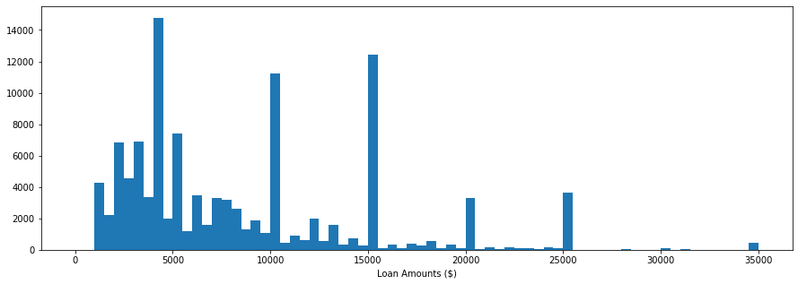

```python
# make histogram of loan amounts
binsize = 500
bins = np.arange(0, df['LoanOriginalAmount'].max()+binsize, binsize)

plt.figure(figsize = [15, 5])
plt.hist(data = df, x = 'LoanOriginalAmount', bins=bins)
plt.xlabel('Loan Amounts ($)')
plt.show()
```

```python
subdf_4k = df.query('LoanOriginalAmount == 4000')
subdf_10k = df.query('LoanOriginalAmount == 10000')
subdf_15k = df.query('LoanOriginalAmount == 15000')
```

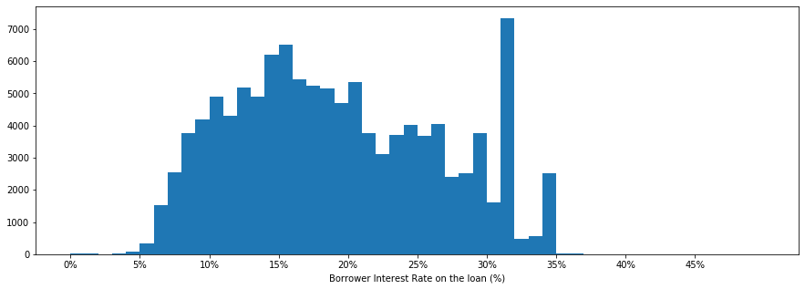

```python
# make histogram for interest rates
binsize = 0.01
bins = np.arange(0, df['BorrowerRate'].max()+binsize, binsize)

plt.figure(figsize = [15, 5])
plt.hist(data = df, x = 'BorrowerRate', bins = bins)
tick_props = np.arange(0, 0.5, 0.05)
tick_names = ['{:0.0f}%'.format(v*100) for v in tick_props]
plt.xticks(tick_props, tick_names)
plt.xlabel('Borrower Interest Rate on the loan (%)')
plt.show()
```

The rates range mainly from 5% to 35% for the loans. The distrbution is skewed a bit to the right. But there is a significant rise at around the rate of 32%.

```python
# subdf with the outlier for further analysis
subdf_032 = df.query('BorrowerRate >= 0.31 and BorrowerRate < 0.33')
```

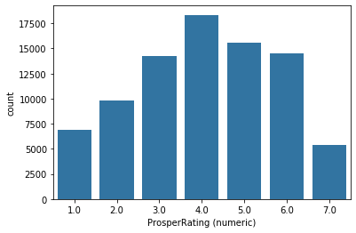

```python
# view distribution on rating category
sb.countplot(data = df, x = 'ProsperRating (numeric)', color = base_color);
```

Looks like a normal distribution. It is noticeable that the gap between second-best (6) and best rating (7) is quite large.

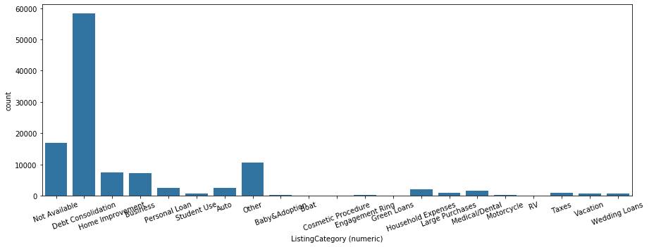

```python
# view loan distribution by use category
cat_labels =['Not Available', 'Debt Consolidation', 'Home Improvement', 'Business', 'Personal Loan', 'Student Use', 'Auto',
               'Other', 'Baby&Adoption', 'Boat', 'Cosmetic Procedure', 'Engagement Ring', 'Green Loans', 'Household Expenses',
               'Large Purchases', 'Medical/Dental', 'Motorcycle', 'RV', 'Taxes', 'Vacation', 'Wedding Loans']
plt.figure(figsize = [15, 5])
sb.countplot(data = df, x = 'ListingCategory (numeric)', color = base_color);
plt.xticks(np.arange(21), cat_labels, rotation = 20);
```

By far the most of the loans (59000, roughly a half) are used for debt consolidation.

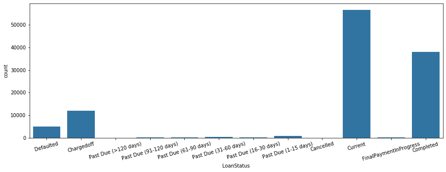

```python
# loan distribution amond the status categories
plt.figure(figsize = [15, 5])
sb.countplot(data = df, x = 'LoanStatus', color = base_color);
plt.xticks(rotation = 15);
```

Major part of the loans is completed or current. However, a not insignificant part is defaulted or charged off.

In a further step, I will explore how the data developed over time.

```python
type(df['ClosedDate'][0])
```

```
str
```

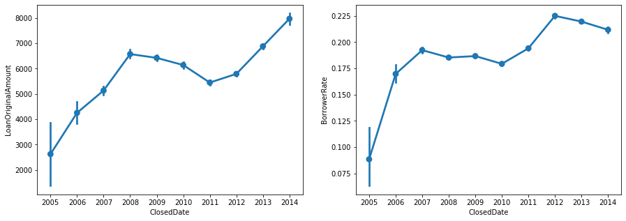

```python
# use a pointplot to find out what was the mean loan value and interest rate for each year
df2 = df.copy()
df2 = df2.dropna(subset = ['ClosedDate'])
df2.ClosedDate = df2.ClosedDate.str[:4]

plt.figure(figsize = [15, 5])
plt.subplot(1, 2, 1)
sb.pointplot(data = df2, x = 'ClosedDate', y = 'LoanOriginalAmount');
plt.subplot(1, 2, 2)
sb.pointplot(data = df2, x = 'ClosedDate', y = 'BorrowerRate');
```

The total loan amounts increased over the years from a mean 2800 USD in 2005 to a mean of 8000 USD in 2014 - the mean amounts almost trippled! The mean interest rates increased slightly from roughly 17% in 2006 to roughly 20% in 2014.

Knowing from the previous plot, that most of the loans were used for consolidation, I have the question whether this development shows an "blowing" up of debt, as these loans might just be rolled over instead of repayed? Also, if we look at the mean interest rates, one conclusion can be drawn, that the same loans are rolled over every due date, but with increasing interest rates. Let's check the debt ratios with a further plot.

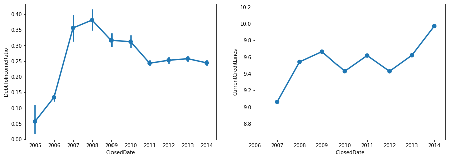

```python
# use a pointplot to check debt development of borrowers over time
plt.figure(figsize = [15, 5])
plt.subplot(1, 2, 1)
sb.pointplot(data = df2, x = 'ClosedDate', y = 'DebtToIncomeRatio');
plt.subplot(1, 2, 2)
sb.pointplot(data = df2, x = 'ClosedDate', y = 'CurrentCreditLines', errwidth=0);
plt.xlim(left=1);
```

Actually, even if the average mean number of credit lines increased (from a mean of 9 line in 2007 to a mean of 10 lines in 2014), the debt to income ratio decreased over time. From the highest rate in 2008 with 36% it decreased to a rough 25% on 2014, which is a total decrease of almost 30%.

It seems that at least the increase in loan amounts are not reflected in an increase in an individual debt ratio. On conclusion I cound draw from this would be that a) just more people get access to loans or b) the incomes increase on a greater rate than the debt does. Let's check for mean income development over time.

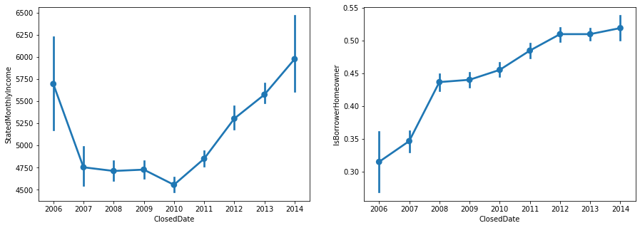

```python
plt.figure(figsize = [15, 5])
df_not2005 = df2.query('ClosedDate != "2005"')
plt.subplot(1, 2, 1)
sb.pointplot(data = df_not2005, x = 'ClosedDate', y = 'StatedMonthlyIncome');
plt.subplot(1, 2, 2)
sb.pointplot(data = df_not2005, x = 'ClosedDate', y = 'IsBorrowerHomeowner');
```

Ignoring the data for 2005 (which seams just to be not correct), an increase in mean monthly incomes by more than 1000 USD can be seen, especially cosidering the development from 2010 to 2014 where mean incomes rise from 4500 USD to 6000 USD (a rise of 30%). This might be the explanation why debt ratio decreases over time.

Also, it is noriceable that the proportion of homeowners increased from approx 32% to 50% over time. This may be also the explanation of the high consolidation amount in this datased: many borrowers might just roll over their house loans at due date, so they are categorized as "debt consolidation" (and actually should be labeled as real estate loans or similar)? Additionally, the consolidation might take place to consolidate the high amount of credit lines (9-10 on average).

The next step will be to review the development of the interest rate, the rating and other potentially incluencing variables.

### Discuss the distribution(s) of your variable(s) of interest. Were there any unusual points? Did you need to perform any transformations?

The loan and interest rate distributions are slightly right skewed. Interestingly, some values stood out, like the interest rate of 32% oder the loan amounts of 4k, 10k and 15k USD. The distribution among rating categories is normal.

Monst of the loans were used for debt consolidation, but which acutally might be real estate loans as the percentage of homeowners among the borrowers increases over time (from 32% in 2007 to 50% in 2014). Additionally, the consolidation might take place to consolidate the high amount of credit lines (9-10 on average).

### Of the features you investigated, were there any unusual distributions? Did you perform any operations on the data to tidy, adjust, or change the form of the data? If so, why did you do this?

Reviewing further features I found that although the mean debt to income ratio decreases over time (from 36% in 2008 to 25% in 2014), and also mean monthly incomes increase over time (from 4500 USD in 2010 to 6000 USD in 2014) the mean interest rate actually does not decrease. Instead it slightly increases from 17% in 2006 to 20% in 2014 - I would have expected the opposite since the financials of the borrower seem to become better ower time.

Also a not insignificant part of the loans is chargedoff / defaulted. There are lots of interesting questions that are beyond the actual scope of my analysis, like testing how chargedoff ratio of loans have developed over time, or what rating categories are associated with this category.

## Bivariate Exploration

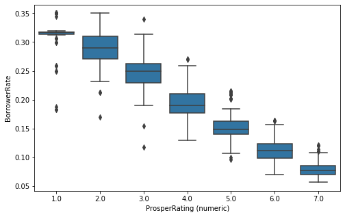

```python
# a boxplot shows best the relationship between rating and price
plt.figure(figsize = [8, 5])
sb.boxplot(data = df_small, x = 'ProsperRating (numeric)', y = 'BorrowerRate', color = base_color);
```

The price increases stepwise. Mean rate for the best category is approx. 7.5% and mean rate for the worst category is 32%. It looks, like there is a clear process that increases the price in a linear way as the rating deteriorates.

It is also a hint for the spike in 32% loans. From the plot we can see, thatin the worst category (1), there is almost no range for the interest, so I would assume that a majority of rating 1 customers just receive a 32% interest rate and have little influence to negotiate a better rate within this category. Additionally, this may be the cap of the bank for risky loans (so almost no loans are provided if standard conditions for receiving a category 1 rating are not met).

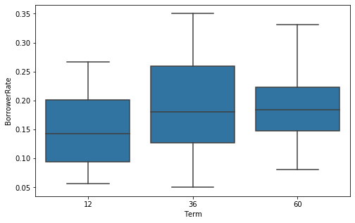

```python
# a further boxplot will show the relationship between Term and price
plt.figure(figsize = [8, 5])
sb.boxplot(data = df_small, x = 'Term', y = 'BorrowerRate', color = base_color);
```

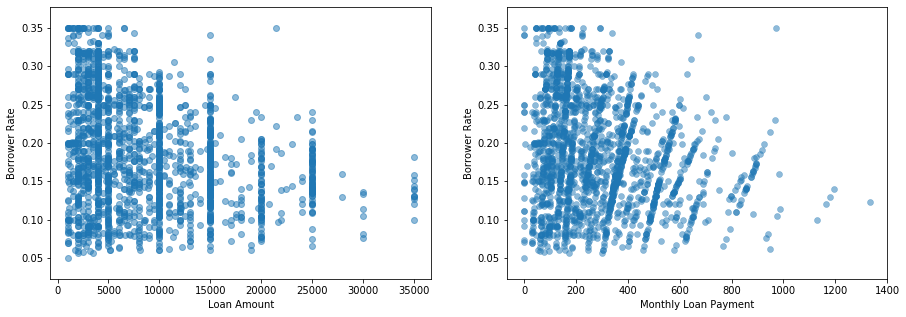

```python
# a scatteplot for loan amount and price relationship
plt.figure(figsize = [15, 5]);
plt.subplot(1, 2, 1)
plt.scatter(data = df_small, x = 'LoanOriginalAmount', y='BorrowerRate', color = base_color,
            alpha = 0.5, linewidths = 1);
plt.ylabel('Borrower Rate');
plt.xlabel('Loan Amount');
plt.subplot(1, 2, 2)
plt.scatter(data = df_small, x = 'MonthlyLoanPayment', y='BorrowerRate', color = base_color, alpha=0.5, linewidths=0.5);
plt.ylabel('Borrower Rate');
plt.xlabel('Monthly Loan Payment');
```

The price is negatively correlated to the loan amount (i.e. greater loans show lower rates). I suppose, there is a causality, as banks should be unlikely giving big loans to customers with bad ratings, so in turn customers with better rating receive bigger loans and the better ratings lead to lower interest rates for these loans in general.

Also there is a alightly negative correlation to monthly loan payments (as the rate increases, people want to repay faster).

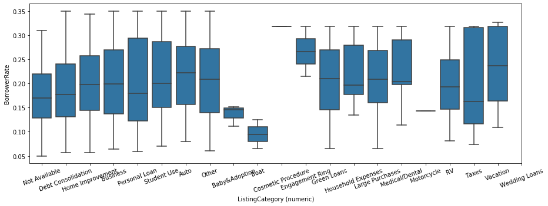

```python
# a boxplot for category and mean rate
plt.figure(figsize = [15, 5]);
sb.boxplot(data = df_small, x = 'ListingCategory (numeric)', y = 'BorrowerRate', color = base_color);
plt.xticks(np.arange(21), cat_labels, rotation = 20);
```

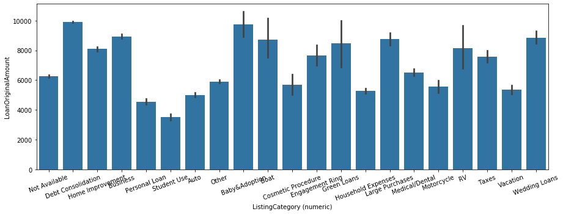

```python
# barplot for mean loan amount values and loan category
plt.figure(figsize = [15, 5]);
sb.barplot(data = df, x = 'ListingCategory (numeric)', y = 'LoanOriginalAmount', color = base_color);
plt.xticks(np.arange(21), cat_labels, rotation = 20);
```

The loans with the highest count in the dataset (debt consolidation) also have the highest mean amount. Probably, a significant influence on the development on the average of interest rates is partly to these loans. The lowest mean loan amounts were given for student loans, bigger amounts were given (among others) for Baby&Adoption, Boats or Wedding Loans.

In a next step, I will analyse how the interest rate changes over a period of a year.

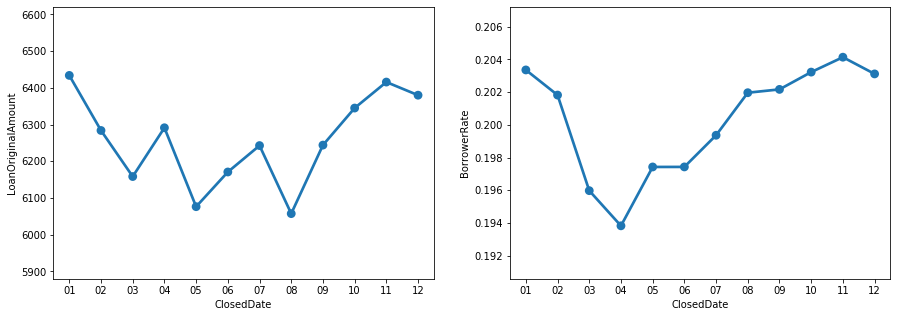

```python
# use a pointplot to find out what was the mean loan value and interest rate for each month
df3 = df.copy()
df3 = df3.dropna(subset = ['ClosedDate'])
df3.ClosedDate = df3.ClosedDate.str[5:7]

plt.figure(figsize = [15, 5])
plt.subplot(1, 2, 1)
sb.pointplot(data = df3, x = 'ClosedDate', y = 'LoanOriginalAmount', color = base_color, errwidth = 0);
plt.subplot(1, 2, 2)
sb.pointplot(data = df3, x = 'ClosedDate', y = 'BorrowerRate', errwidth = 0);
```

Over the year, we can see that through November to January the highest mean loan amounts were granted. Not surprisingly, also the mean interest rates are the highest. So, if we need a loan, we best got to the bank in April.

Finally, I will check for the relationship between price and status.

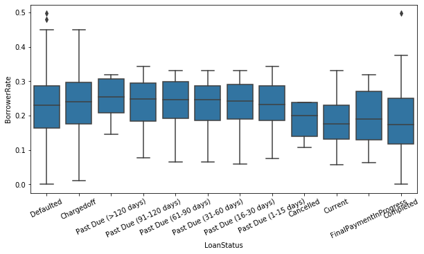

```python
plt.figure(figsize = [10, 5])
sb.boxplot(data = df, x = 'LoanStatus', y = 'BorrowerRate', color = base_color);
plt.xticks(rotation = 25);
```

### Talk about some of the relationships you observed in this part of the investigation. How did the feature(s) of interest vary with other features in the dataset?

Also, loans with greater monthly installments have lower interest rates (as the rate increases, people want to repay faster). The price is also negatively correlated to the loan amount (i.e. greater loans show lower rates because they are mainly given to people with better rating categories).

## Multivariate Exploration

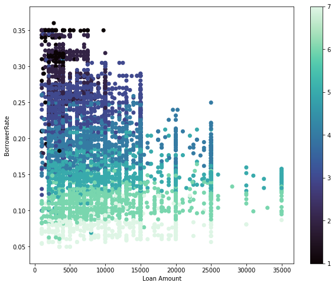

```python
# a scatteplot for loan amount and price and ratig relationship
plt.figure(figsize = [10, 8])
plt.scatter(data = df_med, x = 'LoanOriginalAmount', y = 'BorrowerRate', c = 'ProsperRating (numeric)',
            cmap = 'mako', linewidths = 1);
plt.colorbar();
plt.ylabel('BorrowerRate');
plt.xlabel('Loan Amount');
```

The negative correlation is clearly visible, also the different rating category, which are quite sharply defined within thier interest ranges. Here, we can see that big loans (> 15000 USD) are granted almost only from category 4 upwards.

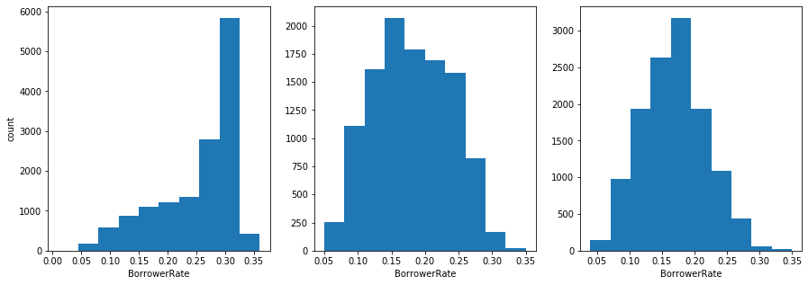

```python
# three plots for each: 4k, 10k and 15k loans to show distribution of rates
plt.figure(figsize = [15, 5]);
plt.subplot(1, 3, 1)
plt.hist(data= subdf_4k, x = 'BorrowerRate', color = base_color);
plt.xlabel('BorrowerRate');
plt.ylabel('count');
plt.subplot(1, 3, 2)
plt.hist(data= subdf_10k, x = 'BorrowerRate', color = base_color);
plt.xlabel('BorrowerRate');
plt.subplot(1, 3, 3)
plt.hist(data= subdf_15k, x = 'BorrowerRate', color = base_color);
plt.xlabel('BorrowerRate');
```

This additionally underlines the distribution of the interest rates within the loan amounts. We can see the interest outlier (32% loan), that has by far the greatest count (6000) for small 4000 USD loans.

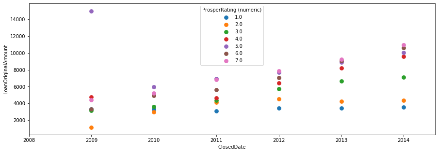

```python
plt.figure(figsize = [15, 5]);
sb.pointplot(data = df2, x = 'ClosedDate', y = 'LoanOriginalAmount', hue = 'ProsperRating (numeric)',
            linestyles = '', errwidth = 0);
plt.xlim(left = 3);
```

Let's see how the portfolio of ratings changed over time. The mean loan amounts increased (as seen in previous plot in univariate explorations section).

So we see, that mean loan amounts increase over time. Even though there is an increase among "bad" loans with bad rating categories, the increase among the good rating (3 and better) categories outweight this deveopment. Conclusions from this could be that

a) the banks are willing to take less risks over time and shift their portfolio towards better rating categories,

b) nevertheless the interest rate increases, but which is not because the bank take increasingly higher risks (and bad ratings) but due to other develeopments (bank may increase their fees and interest due to market rates, internal administrative process costs increase etc) or

c) the rating might be reclassified over time, such that borrowers with previously bad rating categories wer increasingly classified in good rating categories. This may look good in the bank's portfolio, but this will still increase their risk over time, so the bank may have decided to increase interest rates in turn.

I will funally explore which variables may influence the rating.

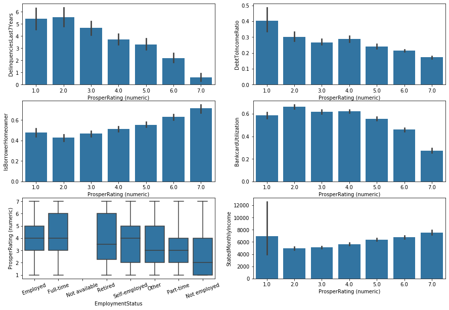

```python
# barplots and boxplots for showing relationship of different variables to rating category
plt.figure(figsize = [15, 10]);
plt.subplot(3, 2, 1)
sb.barplot(data = df_med, x = 'ProsperRating (numeric)', y = 'DelinquenciesLast7Years', color = base_color);
plt.subplot(3, 2, 2)
sb.barplot(data = df_med, x = 'ProsperRating (numeric)', y = 'DebtToIncomeRatio', color = base_color);
plt.subplot(3, 2, 3)
sb.barplot(data = df_med, x = 'ProsperRating (numeric)', y='IsBorrowerHomeowner', color = base_color);
plt.subplot(3, 2, 4)
sb.barplot(data = df_med, x = 'ProsperRating (numeric)', y = 'BankcardUtilization', color = base_color);
plt.subplot(3, 2, 5)
sb.boxplot(data = df_med, x = 'EmploymentStatus', y='ProsperRating (numeric)', color = base_color);
plt.xticks(rotation=20);
plt.subplot(3, 2, 6)
sb.barplot(data = df_med, x = 'ProsperRating (numeric)', y = 'StatedMonthlyIncome', color = base_color);
```

Rating is correlated to:

- Delinquencies: if less, then rating will be better
- Debt Ratio: if less, the rating will be better
- Homeowner: homeowners were more likely to have a good rating
- Bankcard Utilization: if Bankcard was not utilized, the rating increases
- Employment Status: Not employed have clearly the worst ratings
- Income: Also income is a hint for better rating

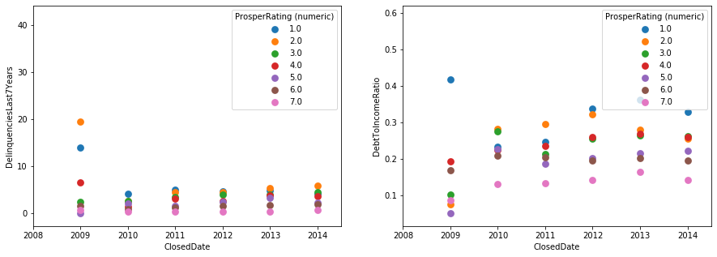

```python
plt.figure(figsize = [15, 5]);
plt.subplot(1, 2, 1)
sb.pointplot(data = df2, x = 'ClosedDate', y = 'DelinquenciesLast7Years', hue = 'ProsperRating (numeric)',
             errwidth=0, linestyles="");
plt.xlim(left=3);
plt.subplot(1, 2, 2)
sb.pointplot(data = df2, x = 'ClosedDate', y = 'DebtToIncomeRatio', hue = 'ProsperRating (numeric)',
            errwidth=0, linestyles="");
plt.xlim(left=3);
```

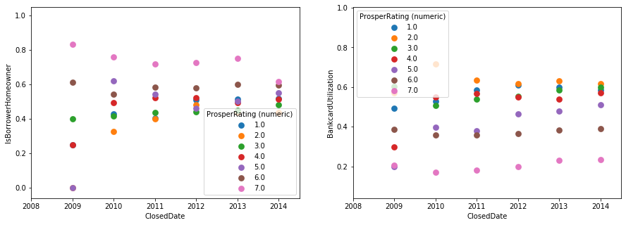

```python
plt.figure(figsize = [15, 5]);
plt.subplot(1, 2, 1)
sb.pointplot(data = df2, x = 'ClosedDate', y='IsBorrowerHomeowner', hue = 'ProsperRating (numeric)',
            errwidth=0, linestyles="");
plt.xlim(left=3);
plt.subplot(1, 2, 2)
sb.pointplot(data = df2, x = 'ClosedDate', y = 'BankcardUtilization', hue = 'ProsperRating (numeric)',
             errwidth=0, linestyles="");
plt.xlim(left=3);
```

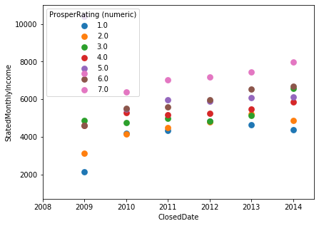

```python
plt.figure(figsize = [15, 5]);
plt.subplot(1, 2, 1)
sb.pointplot(data = df2, x = 'ClosedDate', y = 'StatedMonthlyIncome', hue = 'ProsperRating (numeric)',
            errwidth=0, linestyles="");
plt.xlim(left=3);
```

The mean monthly income increases for all categories, escpecially compared to 2009. in 2013 and 2014 the increase is strongest for the best rating category (7) and suprisingly the bad categories (1, 2) show a decrease in 2014.

### Talk about some of the relationships you observed in this part of the investigation. Were there features that strengthened each other in terms of looking at your feature(s) of interest?

As previously suggested, there is a relationship between BorrowerRate, Rating and Loan amount. The greater the loan amount, the better must be the rating. Over time loan amounts increased for all rating categories.

I have plotted different variables to review what might influence the rating score. Debt to income ratio is strongly correlated with the rating, as well as the number of delinquencies. If the borrower was a homeowner, the rating was likely to be better. Also, if the borrower has not utilized the bankcard before. A full time employment is beneficial for a good rating (as "Part-Time" and "Retired" was only slightly better on the rating scala compared to "Not Employed"). And finally, the income also influences the rating category.

It seems that banks became more likely to provide loans to people: For borrowers with good rating the loan amounts increased over time, and this may be also covered by a positive financial development of the borrowers (monthly income, debt ratio). For borrowers with bad rating categories, loan amounts also increased over time. In these particular categories monthly incomes also increased over time, but so did the debt ratio and a greater percentage of borrowers became homeowners.

### Were there any interesting or surprising interactions between features?

An interesting fact is that the rating gives priority to debt ratio over delinquencies, as the category with the lowest rating (1) had lower deliquiency rates compared to the second lowest deliqency rates.

```python
from subprocess import call
call(['python', '-m', 'nbconvert', 'LoanDataProsper_Exploration.ipynb'])
```

```
0
```